# Tvyal Newsletter

2024-11-04

*English summary below.*

Հարգելի գործընկեր,

## [👫📉⚰️ Ժողովրդագրական ճգնաժամ․ 2100 թվականին Հայաստանում 2 միլիոն հայ](https://www.tvyal.com/newsletter/2024/2024_11_04)

Հայաստանը կանգնած է լուրջ ժողովրդագրական մարտահրավերների առջև, որոնք վճռորոշ դեր են խաղալու երկրի ապագայի համար։ Ըստ կանխատեսումների՝ 2100 թվականին Հայաստանի բնակչությունը կարող է նվազել մինչև ընդամենը 2 միլիոն մարդ։ Այս անկումը սպառնում է երկրի տնտեսական և սոցիալական հիմքերին։ Ուսումնասիրենք տվյալները և հասկանանք, թե ինչն է պայմանավորում այս միտումը և ինչ հետևանքներ այն կարող է ունենալ Հայաստանի համար։

Երկարաժամկետ հեռանկարում երկրի տնտեսական աճի ներուժը պայմանավորված է երկու հիմնարար գործոններով՝ ապագա բնակչության թվաքանակով և էներգետիկ ենթակառուցվածքների բարելավմամբ։ Մենք արդեն անդրադարձել ենք Հայաստանի էներգետիկ մարտահրավերներին և հնարավորություններին մեր վերջին վերլուծության մեջ [🔌⚡🇦🇲 էլեկտրիկ Հայաստան․ Ցանցի խոցելիությունից մինչև արևային հեռանկարներ](https://www.tvyal.com/newsletter/2024/2024_09_09)։ Այսօր կքննարկենք ժողովրդագրական մարտահրավերները, որոնք կարող են արմատապես վերաձևավորել Հայաստանի ապագան։

Գծապատկեր 1

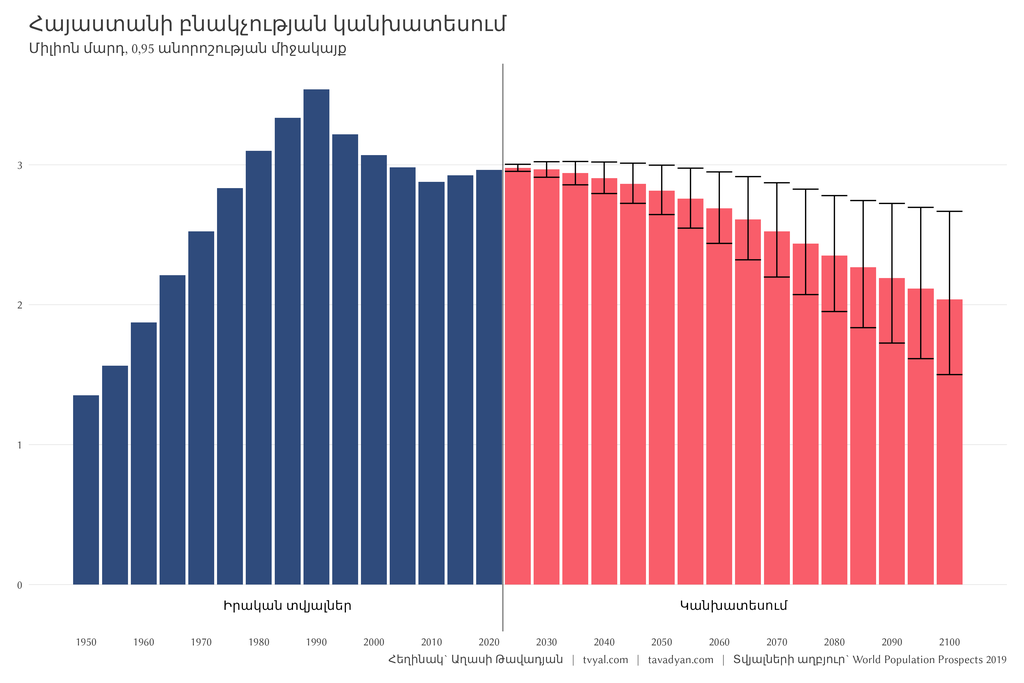

Առաջին գծապատկերը ցույց է տալիս Հայաստանի բնակչության պատմական միտումները և ապագա կանխատեսումները։ Մինչ Ադրբեջանում նկատվում է բնակչության աճ, Հայաստանի ցուցանիշները նվազման միտում ունեն։ Այս անկումը պարզապես թվեր չեն․ սա արտացոլում է հայ հասարակության հիմնարար փոփոխություն, որն ազդելու է ամեն ինչի վրա՝ սկսած տնտեսական աճից մինչև ազգային անվտանգություն։

Կանխատեսված միտումը հիմնված է մինչև 2019թ. գրանցված տվյալների հիման վրա: Կանխատեսման մեջ հաշվի առնված չեն 2020 թվականի 44-օրյա Արցախյան պատերազմի, 2023 թվականի Արցախի կորուստի և որպես հետևանք արցախահայության արտագաղթի, ինչպես նաև ռուս-ուկրաինական հակամարտության հետևանքով Ռուսաստանի Դաշնությունից մոտ 100-140 հազար ռելոկանտների Հայաստան տեղափոխվելու, և վերջին երկու տարիների ընթացքում համեմատաբար մեծ քանակությամբ Հնդկաստանի քաղաքացիների՝ Հայաստան ներգաղթի հանգամանքները: Նշենք, որ ՌԴ 100-140 հազար քաղաքացիների ներգաղթը կազմում է Հայաստանի բնակչության 3-4 տոկոսը: ՌԴ ռելոկանտների զգալի մասը հայ է: [Ըստ նախկին էկոնոմիկայի նախարարի, ռելոկանտների մոտ մեկ երրորդ մասը արդեն 6 ամիս առաջ լքել էր Հայաստանը](https://arm.sputniknews.ru/20240203/inchu-en-relvokantnery-heranum-hhic-pattsharneri-masin-khvosum-en-henc-irenq-ev-pvordzagetnery-71585615.html): Այս զգալի փոփոխությունները դեռևս հաշվի չեն առնված այս կանխատեսման մեջ: Այս ամենը որոշ չափով կարող է մեղմել ժողովրդագրական խնդիրը:

### Պտղաբերության գործակիցը՝ խնդրի էությունը

Բնակչության նվազման հիմքում ընկած է պտղաբերության գործակիցը՝ մեկ կնոջ ծնած երեխաների միջին թիվը։ Բնակչության կայուն մակարդակը պահպանելու համար այս թիվը պետք է լինի մոտավորապես 2.1 երեխա յուրաքանչյուր կնոջ հաշվով (այսպես կոչված՝ փոխարինման մակարդակ)։ Ինչո՞ւ հենց 2.1, և ոչ թե պարզապես 2։ Լրացուցիչ 0.1-ը հաշվի է առնում իրական կյանքի մի շարք գործոններ․ որոշ երեխաներ չեն հասնում չափահասության, ոմանք չեն ունենում սեփական երեխաներ, իսկ մյուսները արտագաղթում են։ Այս փոքր, բայց էական տարբերությունը վճռորոշ է բնակչության կայունությունը պահպանելու համար։

Սակայն Հայաստանում ներկայիս պտղաբերության գործակիցը ընդամենը 1.6 է, ինչը զգալիորեն ցածր է բնակչության պահպանման համար անհրաժեշտ մակարդակից։

Գծապատկեր 2

[figure not shown]

Այս գծապատկերը ցույց է տալիս, թե ինչպես են փոխվել պտղաբերության ցուցանիշները Հայաստանում և հարևան երկրներում ժամանակի ընթացքում։ Միտումը ակնհայտ է․ Հայաստանը, ինչպես նաև իր հարևանների մեծ մասը, արձանագրել են ծնելիության կայուն անկում։ Սակայն կան կարևոր տարածաշրջանային տարբերություններ․

- Ադրբեջանը պահպանել է պտղաբերության ավելի բարձր մակարդակ 1990-ականներին և 2000-ականներին,
- Վրաստանը ցուցաբերում է Հայաստանին նման միտումներ, սակայն որոշակի ժամանակային տարբերությամբ,
- Վրաստանը այս պահին վերականգնել է պտղաբերության 2.1 մակարդակը,
- Թուրքիայի պտղաբերության մակարդակի անկումը ավելի աստիճանական է եղել։
- Ռուսաստանը նշված երկրների մեջ այս պահին ունի պտղաբերության ամենացածր մակարդակը

### Ժողովրդի անկման հաշվարկ

Գծապատկեր 3

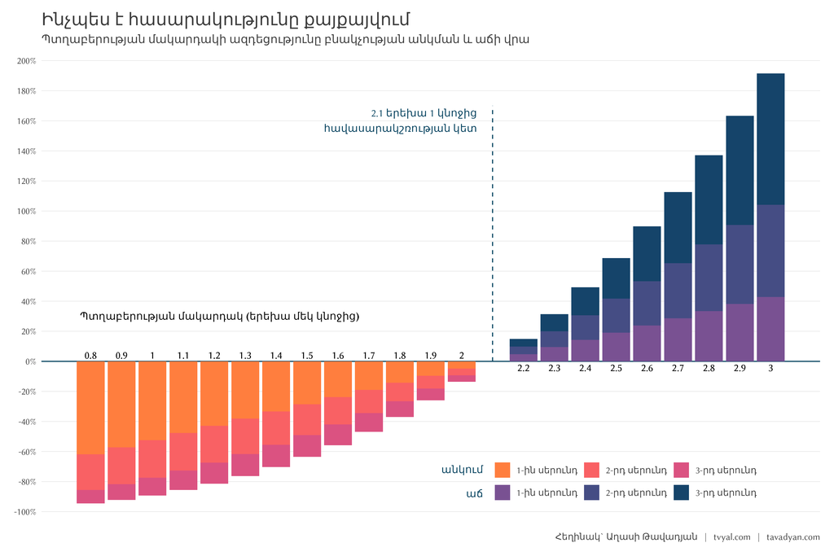

Երրորդ գծապատկերը բացահայտում է բնակչության նվազման մաթեմատիկական իրականությունը սերունդների կտրվածքով։ Հայաստանի ներկայիս 1.6 պտղաբերության գործակցով․

- Առաջին սերունդ (25-30 տարի)․ 23.8% նվազում
- Երկրորդ սերունդ (50-60 տարի)․ 41.9% նվազում
- Երրորդ սերունդ (75-90 տարի)․ Էլ ավելի խորը անկում

Պատկերացնելու համար․ Եթե սկսենք 1000 մարդուց, ներկայիս պտղաբերության դեպքում․

- 2050թ․՝ կնվազի մինչև 762 մարդ
- 2080թ․՝ հետագա նվազում մինչև 581 մարդ
- 2100թ․՝ շարունակական անկում

> Հայաստանի ընտանիքների ուսումնասիրությունը ըստ սեռատարիքային կազմի և եկամտի մակարդակի կարող եք կարդալ այստեղ.

> [👨‍👩‍👧‍👦✨ Ամուր ընտանիք․ հարուստ ընտանիք](https://www.tvyal.com/newsletter/2024/2024_01_26)։

> Ծանոթացեք նաև մեր նախորդ շաբաթական վերլուծությունների հետ

> [👛💨💰 Դատարկ գրպաններ, բարձր աշխատավարձեր](https://www.tvyal.com/newsletter/2024/2024_08_12)

> [🆘🇦🇲🧑🏼‍💻 SOS ՀՀ ՏՏ․ ռազմավարական առաջնահերթությունից մինչև հնարավոր անկում](https://www.tvyal.com/newsletter/2024/2024_08_19)

> [Վերլուծությունների ամբողջական ցանկը այստեղ](https://www.tvyal.com/newsletter)

### Հայաստանում սելեկտիվ աբորտների հիմնախնդիրը

Նշենք, որ 2000 թվականին Հայաստանում 100 նորածին աղջկան բաժին էր ընկնում 117 նորածին տղա, ինչը մեծ շեղում է և առաջացնում է սեռերի դիսբալանս: Այդ տարի այս բացասական հարաբերությունը համեմատած աշխարհի այլ պետությունների ամենամեծն էր Հայաստանում: Այս հանգամանքը հիմնականում բացատրվում է սելեկտիվ աբորտներով, երբ ծնողները կամ ծնողը որոշում են դադարեցնել իգական սեռի պտղի զարգացումը:

Գծապատկերում ներկայացված են նորածին երեխաների սեռերի հարաբերության ամենախոշոր շեղում ունեցող 4 պետությունները (Չինաստան, Ադրբեջան, Հայաստան, Վիետնամ), ինչպես նաև Վրաստանի և աշխարհի մակարդակները:

Գծապատկեր 4

[figure not shown]

Նշենք, որ բնական ծնունդների մակարդակով 100 նորածին աղջկան բաժին է ընկնում 105-ից 106 տղա: Այսինքն՝ առանց սելեկտիվ միջամտության արդեն իսկ առկա է որոշակի անհավասարություն ծննդի պահին: Դրա պատճառն այն է, որ համեմատած աղջիկների տղաները ավելի հավանական է, որ ծնվեն ներառական կամ այլ հիվանդություններով, և հասունացման ընթացքում ավելի հավանական է, որ մահանան: Բնականոն սեռերի հավասարությունը գալիս է սեռական հասունացումից հետո, երբ տղաների և աղջիկների քանակությունը հավասարվում է:

Նշենք, որ մինչև 1990 թվականը Հայաստանը գտնվում էր բնականոն՝ 100 աղջկան 106 տղա մակարդակի վրա: Արցախի առաջին պատերազմից հետո և՛ Հայաստանում, և՛ Ադրբեջանում այս բնականոն հարաբերությունը կտրուկ խախտվեց՝ ի օգուտ տղաների ծննդի, ինչը կարող է բացատրվել նրանով, որ պատերազմի ընթացքում նշանակալի քանակով տղամարդիկ են զոհվել, որի արդյունքում կանայք մոտ 10 տոկոսով տղամարդկանցից ավել էին:

2021 թվականին 100 նորածին աղջկան արդեն բաժին էր ընկնում 109.5 տղա, այսինքն իրավիճակը բարելավվում է: Ակնկալվում է, որ 2028 թվականին Հայաստանը կվերադառնա բնականոն՝ 100 նորածին աղջկան 106 տղա մակարդակին:

### Ազգային անվտանգությունից մինչև մշակույթ

Բնակչության նվազումն ազդում է Հայաստանի՝ ուժեղ պաշտպանական ուժեր պահպանելու կարողության վրա: Տարածաշրջանում, որտեղ անվտանգության մարտահրավերները մշտապես ներկա են, այս ժողովրդագրական փոփոխությունը կարող է լուրջ հետևանքներ ունենալ ազգային անվտանգության համար:

Մեր մշակութային ժառանգությունն էլ է բախվում մարտահրավերների: Երիտասարդների թվի նվազմամբ ավելի դժվար է դառնում պահպանել ավանդական սովորույթների, լեզվի և արվեստի կենսունակությունը: Մեծ է հավանականությունը, որ ներկայիս պահանջարկը և տնտեսական աճը պահպանելու համար աշխատուժն ու բնակչությունը կփոխարինվեն ներգաղթյալներով՝ Ասիայից և Աֆրիկայից, որտեղ պտղաբերության գործակիցը 4-ից բարձր է:

### Ի՞նչ կարելի է անել

Որոշ երկրներ գտել են այս մարտահրավերները հաղթահարելու ուղիներ: Ֆինանսական խթանները երեխաներ ունեցող ընտանիքների համար, մանկապարտեզների աջակցությունը և բնակարանային օժանդակությունը երիտասարդ ընտանիքներին կարող են օգնել բարձրացնել ծնելիության մակարդակը:

Միգրացիոն քաղաքականությունը նույնպես կարող է իր դերն ունենալ: Որակյալ մասնագետների ներգրավման, սփյուռքի հետ կապերի ամրապնդման և ինտեգրման աջակցության ծրագրերը կարող են օգնել մեղմել բնակչության նվազումը:

Տնտեսական բարեփոխումներն էլ են նույնքան կարևոր: Արտադրողականության բարձրացմամբ և նորարարության խթանմամբ Հայաստանը կարող է մասամբ փոխհատուցել աշխատուժի կրճատումը: Տարածաշրջանային զարգացման նախաձեռնությունները կարող են օգնել բնակչության ավելի հավասարաչափ բաշխմանը երկրում:

### Հորդոր կանանց և ընտանիքներին

Թեև կարևոր է հարգել անձնական ընտրությունը, տվյալները հստակ ցույց են տալիս, որ Հայաստանի ապագան կախված է ներկայիս ժողովրդագրական միտումը շրջելուց: Երեխա ունենալը միայն անձնական ընտրություն չէ - դա ներդրում է մեր ազգի ապագայում:

Կանանց աջակցելը կարիերայի և ընտանեկան կյանքի հավասարակշռության հարցում վճռորոշ է: Սա նշանակում է ավելի լավ մայրության նպաստներ, աշխատանքի ճկուն պայմաններ և մատչելի մանկապարտեզներ: Այն երկրները, որոնք հաջողությամբ հաղթահարել են ժողովրդագրական մարտահրավերները, հայտնաբերել են, որ կանանց ընտրության ազատության աջակցությունը՝ թե՛ կարիերայում, թե՛ ընտանեկան կյանքում, հանգեցնում է ավելի լավ արդյունքների:

Երեխա ունենալու որոշումը խորապես անձնական է, բայց հասարակության ապագայի վրա դրա ավելի լայն ազդեցության ըմբռնումը կարող է օգնել կայացնել այս ընտրությունները: Երբ կանայք իրենց աջակցված են զգում թե՛ մասնագիտական, թե՛ մայրական դերերում, ավելի հավանական է, որ նրանք կընտրեն ավելի շատ երեխաներ ունենալ՝ միաժամանակ պահպանելով իրենց կարիերան:

### Հայացք դեպի ապագա

Հայաստանի առջև ծառացած մարտահրավերը միայն թվերի մասին չէ - այն վերաբերում է այն հասարակության տեսակին, որը մենք ցանկանում ենք ստեղծել ապագա սերունդների համար: Այս մարտահրավերները հասկանալով և հիմա գործելով, մենք կարող ենք աշխատել դեպի լուծումներ, որոնք կապահովեն Հայաստանի կենսունակ և կայուն ապագան:

#### **Չկա ապագա սերունդ, չկա ապագա հասարակություն**

### Աշխարհի բնակչության կանխատեսման վահանակ

[Նշենք, որ այս հետազոտության հիման վրա մեր կողմից ստեղծվել է նաև առցանց վահանակ: Վահանակը տրամադրում է բնակչության կանխատեսումներ և ինտերակտիվ գծապատկերներ տարբեր երկրների և տարածաշրջանների համար: Այն մշակված է R և Python ծրագրավորման լեզուների համակցմամբ և Shiny հավելվածներով՝ այս գործիքը ձեզ հնարավորություն կտա ուսումնասիրել բնակչության միտումները տարբեր գծապատկերների միջոցով: Այս ինտերակտիվ հարթակը թույլ է տալիս նաև փոփոխել գծապատկերների ժամանակաշրջանը: Վահանակը ինտերակտիվ է, գծապատկերի տարբեր հատվածներ ցույց են տալիս հավելյալ տվյալներ:](https://tavad.shinyapps.io/population_projection/)

Շնորհակալ կլինեմ, եթե առաջարկներ գրեք ինձ այս վահանակը կատարելագործելու համար, քանի որ մենք ձգտում ենք բարելավել դրա ֆունկցիոնալությունը և օգտագործման հեշտությունը:

Եթե հնարավոր է, խնդրում եմ այս նյութը ուղարկել նաև այն մարդկանց, ում այն կարծում եք կարող է հետաքրքրել:

**ԱՅՍ ՀՈԴՎԱԾԻ ՀՂՈՒՄԸ**

*Թավադյան, Աղ․Ա․ (2024) Ժողովրդագրական ճգնաժամ․ 2100 թվականին Հայաստանում 2 միլիոն հայ [Demographic Crisis: 2 Million Armenians in Armenia by 2100], tvyal.com հարթակ [tvyal.com platform], 04-11-2024․ https://www.tvyal.com/newsletter/2024/2024_11_04*

**Արգելվում է այս հարթակի նյութերը արտատպել առանց հղում կատարելու։**

* **Մեթոդաբանություն**

The projections use standard demographic modeling techniques, accounting for fertility rates, mortality rates, and migration patterns. The population decline calculations are based on generational fertility rate comparisons against the replacement rate of 2.1 children per woman.

Այս և մեր բոլոր այլ վերլուծությունների տվյալները վերցված են պաշտոնական աղբյուրներից։ Հաշվարկները ամբողջությամբ հասանելի են github-ում, դրանք կարելի է ստուգել` այցելելով [github-ի](https://github.com/tavad/tvyal_newsletter/blob/main/2024/) մեր էջը, որտեղ տրված են տվյալները, հաշվարկների և գծապատկերների կոդը։

# ՀԱՄԱԳՈՐԾԱԿՑՈՒԹՅՈՒՆ

## Եթե ուզում եք AI գործիքներով ձեր տվյալներից օգուտ քաղել` ԴԻՄԵՔ ՄԵԶ

### Մենք առաջարկում ենք

- Extensive databases for finding both international and local leads
- Exclusive reports on the Future of the Armenian Economy
- Work and browser automation to streamline operations and reduce staffing needs
- AI models for forecasting growth and optimizing various aspects of your business
- Advanced dashboarding and BI solutions
- Algorithmic trading

### Let’s Put Your Data to Work!

### ՄԻԱՑԵՔ ՄԵՐ ԹԻՄԻՆ

## English Summary

### 👫📉⚰️ Demographic Crisis: 2 Million Armenians in Armenia by 2100

Armenia faces a critical demographic challenge that could fundamentally reshape its future. According to projections, by 2100, Armenia’s population could shrink to just 2 million people - a dramatic decline that threatens not only the country’s economic and social fabric but also its national security and cultural preservation. This decline is driven by a fertility rate of just 1.6 children per woman, well below the replacement rate of 2.1 needed to maintain a stable population.

The implications of this demographic shift are far-reaching and complex. With each passing generation, Armenia faces a roughly 24% population decline, leading to a cascading effect that impacts everything from economic growth to pension systems. This challenge is further complicated by recent historical events like the Artsakh conflict, selective abortion practices that have created gender imbalances, and changing migration patterns including the recent influx of relocants from Russia and workers from India. Without intervention through comprehensive family support policies, immigration reforms, and economic initiatives, Armenia risks not just population decline but also significant changes to its social and cultural landscape.

Հարգանքներով,  
Աղասի Թավադյան  
04.11.2024  
[tvyal.com](https://www.tvyal.com/)  
[tavadyan.com](https://www.tavadyan.com/)

[Was this email forwarded to you? Subscribe here.](https://www.tvyal.com/subscribe)

[Բաժանորդագրվեք](https://www.tvyal.com/subscribe)

**Ուշադրություն. Ձեր էլ.փոստը մեյլլիսթի մեջ է, որի միջոցով ես կիսվում եմ շաբաթական նյութեր, որոնք հիմնականում ներկայացնում են Հայաստանի տնտեսությունը: Նյութերը ներառում են գծապատկերներ, [տվյալների բազաներ](https://github.com/tavad/tvyal_newsletter), տեսանյութեր, հոդվածներ, [առցանց վահանակներ](https://www.tvyal.com/projects), տնտեսական գործիքներ, կանխատեսումներ և հաշվետվություններ: Եթե ցանկանում եք չեղարկել բաժանորդագրությունը, խնդրում եմ տեղեկացրեք ինձ, և ես կհեռացնեմ ձեր էլ. փոստը ցուցակից: Գրեք նաև եթե ունեք մենկնաբանություններ:**

**Important! Your email is part of the mailing list where I share weekly materials primarily focused on the Armenian economy. These materials encompass charts, [databases](https://github.com/tavad/tvyal_newsletter), videos, articles, [online dashboards](https://www.tvyal.com/projects), economic tools, forecasts, and reports. If you wish to unsubscribe, please let me know, and I will remove your email from the list. Please share your comments as well․**